## Bayesian Statistics

What does it mean when election forecasters tell us that a given candidate has a 90% chance of winning? In the context of the urn model this would be equivalent to stating that the probability $p>0.5$ is 90%. But, as we discussed, in the urn model $p$ is a fixed parameter and it does not make sense to talk about probability associated with it. With Bayesian statistics, we assume $p$ is in fact random.

Forecasters also use models to describe variability at different levels. For example, sampling variability, pollster to pollster variability, day to day variability, and election to election variability. One of the most successful approaches used for this are hierarchical models, which can be explained in the context of Bayesian statistics.

### Bayes’ theorem

We start by reviewing Bayes’ theorem. We do this using a hypothetical cystic fibrosis test as an example. Suppose a test for cystic fibrosis has an accuracy of 99%. We will use the following notation:

$$\mbox{Prob}(+ \mid D=1)=0.99$$

$$\mbox{Prob}(- \mid D=0)=0.99$$

with $+$ meaning a positive test and $D$ representing if you actually have the disease (1) or not (0).

Suppose we select a random person and they test positive. What is the probability that they have the disease? We write this as $\mbox{Prob}(D=1 \mid +)$. The cystic fibrosis rate is 1 in 3,900 which implies that $\mbox{Prob}(D=1)=0.00025$. To answer this question we will use Bayes Theorem, which in general tells us that:

$$\mbox{Pr}(A \mid B) = \frac{\mbox{Pr}(B \mid A)\mbox{Pr}(A)}{\mbox{Pr}(B)}$$

This equation applied to our problem becomes:

$$\begin{aligned}
\mbox{Pr}(D=1 \mid +) & = \frac{ P(+ \mid D=1) \cdot P(D=1)} {\mbox{Pr}(+)} \\
& = \frac{\mbox{Pr}(+ \mid D=1)\cdot P(D=1)} {\mbox{Pr}(+ \mid D=1) \cdot P(D=1) + \mbox{Pr}(+ \mid D=0) \mbox{Pr}( D=0)}
\end{aligned}$$

Plugging in the numbers we get:

$$\frac{0.99 \cdot 0.00025}{0.99 \cdot 0.00025 + 0.01 \cdot (.99975)} = 0.02$$

This says that despite the test having 0.99 accuracy, the probability of having the disease given a positive test is only 0.02. This may appear counter-intuitive to some. The reason this is the case is because we have to factor in the very rare probability that a person, chosen at random, has the disease. To illustrate this we run a Monte Carlo simulation.

#### Simulation

The following simulation is meant to help you visualize Bayes’ Theorem. We start by randomly selecting 100,000 people from a population in which the disease in question has a 0.025% prevalence.

```r
prev <- 0.00025
N    <- 100000
outcome <- sample(c("Disease", "Healthy"), N, replace = TRUE, prob = c(prev, 1-prev))
```

Note that there are very few with the disease:

```r
N_D <- sum(outcome == "Disease")
N_D
```

```
## [1] 23
```

```r
N_H <- sum(outcome == "Healthy")
N_H
```

```
## [1] 99977
```

There are also many without the disease which means that we will probably see some false positives given that the test is not perfect. Now each person gets the test which is correct 99% of the time.

```r
accuracy <- 0.99
test <- vector("character",N)
test[outcome == "Disease"]  <- sample(c("+","-"), N_D, replace=TRUE, prob = c(accuracy, 1 - accuracy))
test[outcome == "Healthy"]  <- sample(c("-","+"), N_H, replace=TRUE, prob = c(accuracy, 1 - accuracy))
```

Because there are so many more controls than cases, even with a low false positive rate, we get more controls than cases in the group that tested positive:

```r
table(outcome, test)
```

```
##          test
## outcome       -     +
##   Disease     0    23
##   Healthy 99012   965
```

## Bayes’ in practice

José Iglesias is a professional baseball player. In April 2013, when he was starting his career, he was performing rather well:

| Month | At Bats | H | AVG |
| --- | --- | --- | --- |
| April | 20 | 9 | .450 |

The batting average (`AVG`) statistic is one way of measuring success. Roughly speaking, it tells us the success rate when batting. An `AVG` of .450 means José has been successful 45% of the times he has batted (`At Bats`) which is rather high, historically speaking. Note, for example, that no one has finished a season with an `AVG` of .400 or more since Ted Williams did it in 1941! To illustrate the way hierarchical models are powerful, we will try to predict José’s batting average at the end of the season. In a typical season, players have about 500 at bats.

With the techniques we have learned up to now, referred to as *frequentist techniques*, the best we can do is provide a confidence interval. We can think of outcomes from hitting as a binomial with a success rate of $p$. So if the success rate is indeed .450, the standard error of just 20 at bats is:

$$\sqrt{\frac{.450 (1-.450)}{20}}=.111$$

This means that our confidence interval is .450-.222 to .450+.222 or .228 to .672.

This prediction has two problems. First, it is very large, so not very useful. Second, it is centered at .450 which implies that our best guess is that this new player will break Ted Williams’ record.

If you follow baseball, this last statement will seem wrong and this is because you are implicitly using a hierarchical model that factors in information from years of following baseball. Here we show how we can quantify this intuition.

First, let’s explore the distribution of batting averages for all players with more than 500 at bats during the previous three seasons:

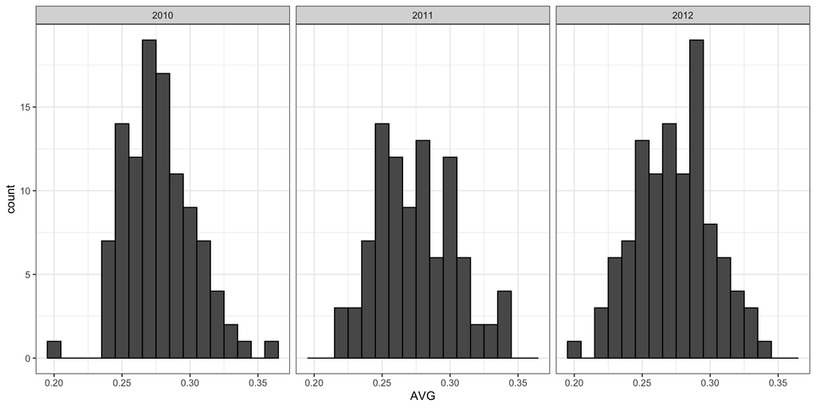

Batting average histograms for 2010, 2011, and 2012.

We note that the average player had an `AVG` of .275 and the standard deviation of the population of players was 0.027. So we can see already that .450 would be quite an anomaly since it is over six standard deviations away from the mean.

So is José lucky, or the best batter seen in the last 70 years? Perhaps it’s a combination of both. But how lucky and how good is he? If we become convinced that he is lucky, we should trade him to a team that trusts the .450 observation and is maybe overestimating his potential.

### The hierarchical model

The hierarchical model provides a mathematical description of how we came to see the observation of .450. First, we pick a player at random with an intrinsic ability summarized by, for example, $p$, then we see 20 random outcomes with success probability $p$.

We use a model to represent two levels of variability in our data. First each player is assigned a nature ability to hit at birth. We will use the symbol $p$ to represent this ability. You can think of $p$ as the batting average you would converge to if this particular player batted over and over again.

Based on the plots above we assume that $p$ has a normal distribution with expected value .275 and standard error 0.027.

Statistical textbooks will write the model like this:
$$\begin{aligned}
p &\sim N(\mu, \tau^2) \mbox{ describes randomness in picking a player}\\
Y \mid p &\sim N(p, \sigma^2) \mbox{ describes randomness in the performance of this particular player}
\end{aligned}$$

with $\mu = .275$, $\tau = 0.027$, and $\sigma^2 = p(1-p)/N$.

Note the two levels (this is why we call them hierarchical): 1) Player to player variability and 2) variability due to luck when batting. In a Bayesian framework, the first level is called a *prior distribution* and the second the *sampling distribution*.

Now, let’s use this model for José’s data. Suppose we want to predict his innate ability in the form of his *true* batting average $p$. This would be the hierarchical model for our data:

$$\begin{aligned}
p &\sim N(.275, .027^2) \\
Y \mid p &\sim N(p, .111^2)
\end{aligned}$$

We now are ready to compute a posterior distribution to summarize our prediction of $p$. The continuous version of Bayes’ rule can be used here to derive the *posterior probability function*, which is the distribution of $p$ assuming we observe $Y=y$. In our case we can show this follows a normal distribution with expected value:

$$\begin{aligned}
\mbox{E}(p \mid y) &= B \mu + (1-B) Y\\
&= \mu + (1-B)(Y-\mu)\\
B &= \frac{\sigma^2}{\sigma^2+\tau^2}
\end{aligned}$$

Note that this is a weighted average of the population average $\mu$ and the observed data $Y$. The weight depends on the SD of the population $\tau$ and the SD of our observed data $\sigma$. This weighted average is sometimes referred to as *shrinking* because it *shrinks* estimates towards a prior mean. In the case of José Iglesias, we have:

$$\begin{aligned}
\mbox{E}(p \mid Y=.450) &= B \times .275 + (1 - B) \times .450 \\
&= .275 + (1 - B)(.450 - .275) \\
B &=\frac{.111^2}{.111^2 + .027^2} = 0.944\\
\mbox{E}(p \mid Y=450) &\approx .285
\end{aligned}$$

The standard error can be shown to be:

$$\mbox{SE}(p\mid y)^2 = \frac{1}{1/\sigma^2+1/\tau^2}
= \frac{1}{1/.111^2 + 1/.027^2} = 0.00069$$
and the standard deviation is therefore $0.026$. So we started with a frequentest 95% confidence interval that ignored data from other players and summarized just José’s data: .450 $\pm$ 0.220. Then we used a Bayesian approach that incorporated data from other players and other years to obtain a posterior probability. This is actually referred to as an empirical Bayes approach because we used data to construct the prior. From the posterior we can report what is called a 95% credible interval by reporting a region, centered at the mean, with a 95% chance of occurring. In our case, this turns out to be: .285 $\pm$ 0.052.

The Bayesian credible interval suggests that if another team is impressed by the .450 observation, we should consider trading José as we are predicting he will be just slightly above average. Interestingly, the Red Sox traded José to the Detroit Tigers in July. Here are the José Iglesias batting averages for the next five months.

| Month | At Bat | Hits | AVG |
| --- | --- | --- | --- |
| April | 20 | 9 | .450 |
| May | 26 | 11 | .423 |
| June | 86 | 34 | .395 |
| July | 83 | 17 | .205 |
| August | 85 | 25 | .294 |
| September | 50 | 10 | .200 |
| Total w/o April | 330 | 97 | .293 |

Although both intervals included the final batting average, the Bayesian credible interval provided a much more precise prediction. In particular, it predicted that he would not be as good the remainder of the season.